# Learn how to learn

Jared

2018-02-26

从整体出发，看看课程的介绍： https://www.coursera.org/learn/ruhe-xuexi/home/info

## 几个核心问题

1. 课程介绍

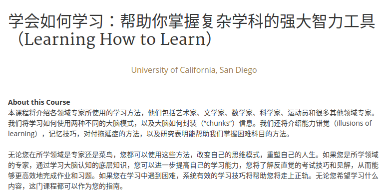

课程包含知识点包括：

- 大脑两种思维模式
- 组块化
- 在长期记忆里创建牢固的组块，解决拖延症，了解记忆
- 提升学习能力的重要概念和技巧
2. 导师介绍

女老师有故事的女人，男老师是计算神经科学的学者。

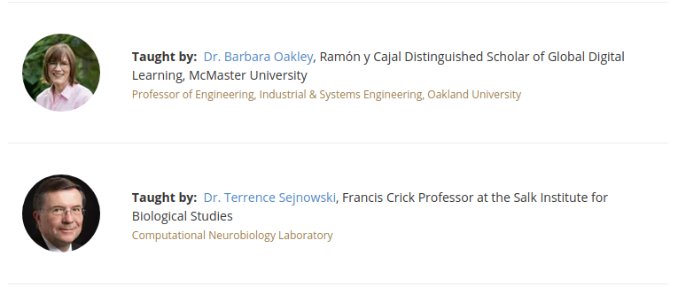

3. 什么是学习？

人类的学习设计到多个维度，包括思维模式，组块化和记忆。知识是长在脑子里面牢固的神经连接，学习就是建立这种连接的过程。

## Week 1: 学习的基本知识点

第一周开头就介绍 focused mode VS diffuse mode

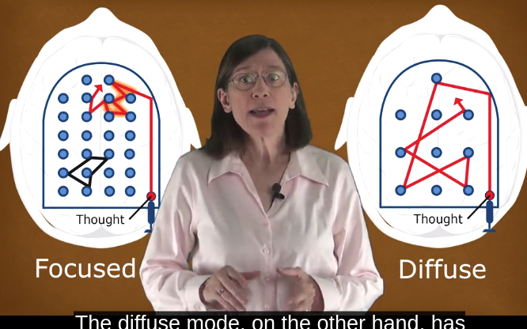

这个最基本的知识点。然后回答什么是学习，介绍学习的相关维度，包括**拖延症**，**记忆**，给出一个特别的提示作为悬念。

- 拖延症

[figure not shown]

- 记忆 Practice and spaced repetition

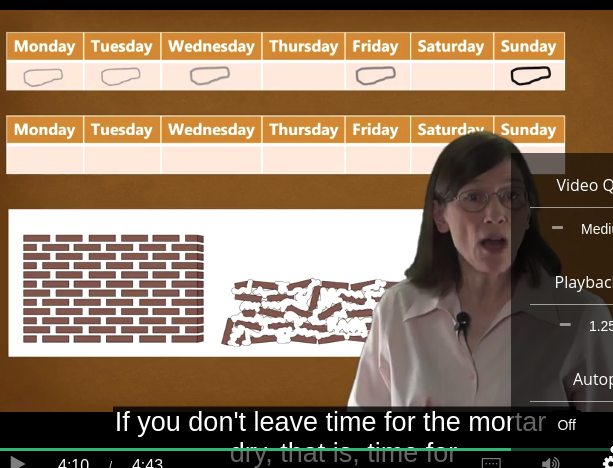

And just as importantly, **exercise is surprisingly valuable** in helping improve both our memory and our ability to learn.

### 英语背诵

Now as far as neuroscientists know right now, **you’re either in the focused mode or the diffuse mode of thinking.** It seems you can’t be in both thinking modes at the same time. **It’s kind of like a coin. We can see either one side, or the other side of the coin.** But not both sides at the same time. **Being in one mode seems to limit your access to the other mode’s way of thinking.**

几个单词：

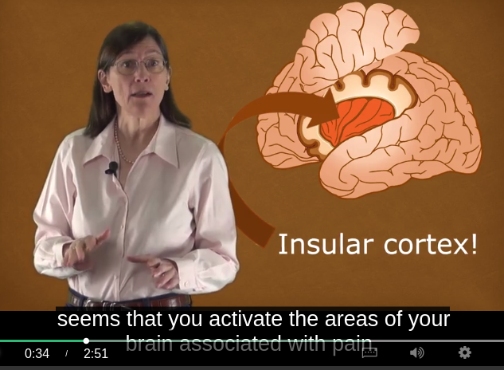

[figure not shown]